# 14 DEEP NEURAL NETWORKS

## 14.1 History

#### Ups & Downs of Neural Networks

NNs and AI have experienced several hype cycles, followed by disappointment, criticism, and funding cuts:

- **1950s - 70s**: Golden years of AI (funded by DARPA): solve algebra, play chess & checkers, reasoning, semantic nets “within ten years a digital computer will be the world’s chess champion”
- **1969**: shown that XOR problem cannot be solved by Perceptron (led to the invention of multi-layer networks later on)
- **Mid 1970s**: Chain reaction that begins with pessimism in the AI community, followed by pessimism in the press, followed by a severe cutback in funding, followed by the “end” of serious research (“AI winter”)
- **1980s**: Governments (starting in Japan) and industry provide AI with billions of dollars. Boom of “expert systems”.
- **1986**: Backpropagation had been invented in the 1970s, but only 1986 it became popular through a famous paper by David Rumelhart, Geoffrey Hinton, and Ronald Williams. It showed that also complex functions became solvable through NNs by using multiple layers.
- **Late 1980s**: Investors - despite actual progress in research - became disillusioned and withdrew funding again.

#### Why no Deep Learning in the 1980s?

Neural Networks could not become “deep” yet - because:

- Computers were slow. So the neural networks were tiny and could not achieve (the expected) high performance on real problems.
- Datasets were small. There were no large datasets that had enough information to constrain the numerous parameters of (hypothetical) large neural networks.
- Nobody knew how to train deep nets. Today, object recognition networks have > 25 successive layers of convolutions. In the past, everyone was very sure that such deep nets cannot be trained. Therefore, networks were shallow and did not achieve good results.

#### Ups & Downs of Neural Networks

- **1991**: Hornik proved 1 hidden layer network can model any continuous function (universal approximation theorem)
- **1991-1992**: Vanishing Gradient, problem in multi-layer networks where training in front layers is slow due to backpropagation diminishing the gradient updates through the layers. Identified by Hochreiter & Schmidhuber who also proposed solutions.
- **1990s - mid 2000s**: Due to lack of computational power, interest in NNs decreased again and other Machine Learning models, such as Bayesian models, Decision Trees and Support Vector Machines became popular.

#### Resurrection of Deep Learning

- **2000s**: Hinton, Bengio and LeCun (“The fathers of the age of deep learning”) join forces in a project. They overcome some problems that caused deep networks not to learn anything at all
- **2006**: Breakthrough with Layer-wise pre-training by unsupervised learning (using RBMs)
- **2010s** - present: Important new contributions:
  - Simpler initialization (without pre-training)
  - Dropout
  - Simplier activations: Rectifier Units (ReLUs)
  - Batch Normalization

  $\to$ not a re-invention of NNs but paved the way for very deep NNs

## 14.2 Architecture

#### Deep Learning vs. Classical Machine Learning

[figure not shown]

#### Deep neural network (DNN)

- Deep neural networks (DNNs) are basically ANNs with multiple hidden layers between the input and output layers.

[figure not shown]

### Activation functions

#### Activation functions

[figure not shown]

- ReLU function
  $$\begin{equation}
  a=\text{ReLU}(x)=\max(0,x)=\begin{cases}
  x & x\geq0\\
  0 & x<0
  \end{cases}
  \end{equation}$$

[figure not shown]

- Leaky ReLU function
  $$\begin{equation}
  a=\text{LeakyReLU}(x)=\max(\alpha x,x)=\begin{cases}
  x & x\geq0\\
  \alpha x & x<0
  \end{cases}
  \end{equation}$$

[figure not shown]

- ELU function
  $$\begin{equation}
  a=\text{ELU}(x)=\begin{cases}
  x & x\geq0\\
  \alpha(\exp(x)-1) & x<0
  \end{cases}
  \end{equation}$$

[figure not shown]

#### Maxout Gate

- The maxout unit takes a group of input activations and ouput the maximum value

$$\begin{equation}
f(\boldsymbol{x})=f(x_{1},x_{2},...,x_{k})=\max_{i}(x_{i})
\end{equation}$$

[figure not shown]

### Why Deep?

#### Why Deep?

**Experiment**

- Deep networks are empirically better in solving many real-world problems
- Deep networks is providing breakthrough results in speech recognition and image classification

  | **Network** | **Error** | **Layers** |
  | --- | --- | --- |
  | AlexNet | 16.0% | 8 |
  | ZFNet | 11.2% | 8 |
  | VGGNet | 7.3% | 19 |
  | GoogLeNet | 6.7% | 22 |
  | MS ResNet | 3.6% | 152! |

[figure not shown]

**Analogy**

**Logic circuits**

**Neural network**

- Logic circuits consists of **gates**
- Neural network consists of **neurons**
- **A two layers** of logic gates can represent any Boolean function.
- **A hidden layer** network can represent any continuous function.
- Using multiple layers of logic gates to build some functions are much **simpler**
- Using multiple layers of neurons to represent some functions are much **simpler**

$\to$ less gates needed

$\to$ less parameters

**Another reason**

[figure not shown]

#### Learning with DNNs

- **Feature hierarchies** (feature engineering) are learnt such that features from higher levels formed by the composition of lower level features.

[figure not shown]

#### Learning Multiple Levels of Abstraction

- The big payoff of deep learning is to allow learning higher levels of abstraction
- Higher-level abstractions disentangle the factors of variaton, which allows much easier generalization and transfer

[figure not shown]

#### Types of Deep neural networks

- Convolutional neural network (CNN)
- Recurrent Neural Networks (RNN)
- Autoencoders
- Generative Adversarial Nets (GAN)
- Region Based CNN (R-CNN)
- YOLO
- RNN ConvNet
- BERT Models
- GPT Models
- Transformer Models

## 14.3 Design

#### Deep Learning Framework

[figure not shown]

#### Design by GUI

[figure not shown]

#### Design by Code

[figure not shown]

## 14.4 Visualization

#### MLP Style

[figure not shown]

#### Lenet Style

- 2.5 D style
- Lenet

[figure not shown]

#### Alex Style

- 3D style
- Alexnet

[figure not shown]

#### Simple Style

[figure not shown]

- 2D style
- VGG16 has 16 layers, not counting the maxpool layers and the softmax at the end

## 14.5 Learning Problem

#### Why are deep neural networks hard to train?

- There’s an **intrinsic instability** associated to learning by **gradient descent** in many-layer (deep) neural networks
- This instability tends to result in either the early or the later layers getting stuck during training
  - The **vanishing gradient problem** and
  - The opposite of this problem is called the **exploding gradient problem**

[figure not shown]

### Vanishing gradient problem

#### The vanishing gradient problem

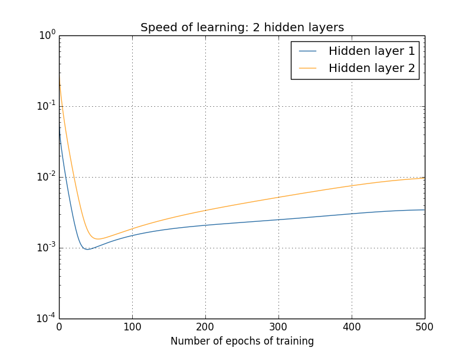

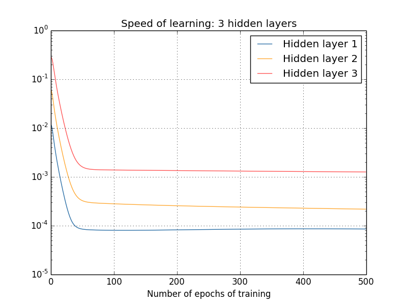

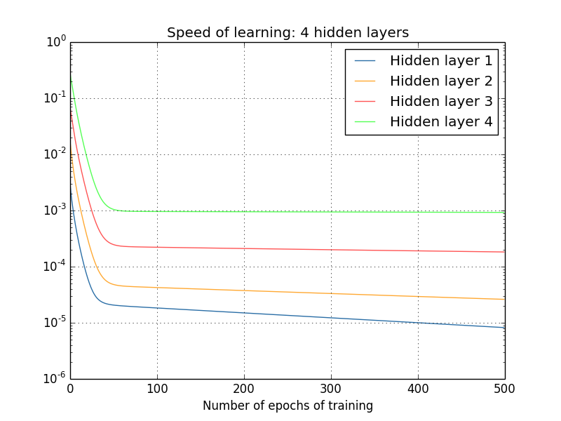

#### What’s causing the vanishing gradient problem?

[figure not shown]

### Nonsaturating Activation Functions

#### ReLU

**Rectified linear units** (ReLU) allow for faster and effective training of DNNs on large and complex datasets.

- **Biological plausibility**
  - One-sided, compared to the anti-symmetry of $\tanh$
- **Sparse activation**
  - E.g., in a randomly initialized network, only about 50% of hidden units are activated (having a non-zero output)
- **Better gradient propagation**
  - Fewer vanishing gradient problems compared to sidgmoid activation functions that saturate in both directions
- **Efficient computation**: Only comparison
- **Scale-invariant**
  $$\forall x,\max(0,ax)=a\max(0,x)$$

#### How does a ReLU work?

[figure not shown]

#### ReLU: Potential issues

- Non-differentiable at zero
  - However, it is differentiable anywhere else, including points arbitrarily close to (but not equal to) zero.
- Non-zero centered
- Unbounded
- Dying ReLU problem

### Dropout

#### Dropout

- **Dropout** is a technique for regularization. Unlike $L_{1}$ and $L_{2}$ regularization, dropout doesn’t rely on modifying the cost function. Instead, in dropout we modify the network structure itself.

[figure not shown]

#### Training Procedure

For each mini-batch

- Start by randomly (and temporarily) deleting $p\%$ the hidden neurons in the network, while leaving the input and output neurons untouched
- We forward-propagate the input through the modified network, and then back-propagate the result to update the appropriate weights and biases

[figure not shown]

#### Testing Procedure

Using original neural network, no dropout

- If the dropout rate at training is $p\%$, all the weights times $(1-p)\%$; e.g., assume that the dropout rate is $p=40\%$, if a weight $w_{train}=1$ by training, set $w_{test}=0.6$ for testing

[figure not shown]

#### Why it works

There two ways of understanding why this works

- This makes the network unable to relay on a single feature

[figure not shown]

- It can also be seen as training a large ensemble of models that share parameters

[figure not shown]

### Batch Normalization

#### Batch Normalization

- **Batch normalization** reparametrizes the model to make artificial neural networks faster and more stable
- **Key idea**: normalize, shift and rescale data
- **Learning**

  | **Input**: | Values of $x$ over a **training set** mini-batch, each of size $m$: $\mathcal{B}=\{x^{(1..m)}\}$ |
  | --- | --- |
  |  | Parameters to be learned: ${\color{red}\gamma}$, ${\color{red}\beta}$ |
  | **Output**: | $\{y^{(i)}=\textrm{BN}_{{\color{red}\gamma},{\color{red}\beta}}(x^{(i)})\}$ |
  |  | ${\color{red}\mu}_{\mathcal{B}}\leftarrow{\displaystyle \frac{1}{m}{\displaystyle \sum_{i=1}^{m}x^{(i)}}}$ (mini-batch mean) |
  |  | ${\color{red}\sigma}_{\mathcal{B}}^{2}\leftarrow{\displaystyle \frac{1}{m}{\displaystyle \sum_{i=1}^{m}(x^{(i)}-{\color{red}\mu}_{\mathcal{B}})^{2}}}$ (mini-batch variance) |
  |  | $\hat{x}^{(i)}\leftarrow{\displaystyle \frac{x^{(i)}-{\color{red}\mu}_{\mathcal{B}}}{\sqrt{{\color{red}\sigma}_{\mathcal{B}}^{2}+\epsilon}}}$ (normalize) |
  |  | $y^{(i)}\leftarrow{\color{red}\gamma}\hat{x}^{(i)}+{\color{red}\beta}$ (scale and shift) |

- **Inference**

  | **Input**: | $x$ |
  | --- | --- |
  | **Output**: | $y$ |
  |  | $\text{E}(x)\gets\text{E}_{\mathcal{B}}[{\color{red}\mu}_{\mathcal{B}}]$ |
  |  | $\text{Var}(x)\gets\dfrac{m}{m-1}\text{E}_{\mathcal{B}}[{\color{red}\sigma}_{\mathcal{B}}^{2}]$ |
  |  | $y=\dfrac{{\color{red}\gamma}}{\sqrt{\text{Var}(x)+\epsilon}}x+\left({\color{red}\beta}-\dfrac{{\color{red}\gamma}\text{E}(x)}{\sqrt{\text{Var}(x)+\epsilon}}\right)$ |

- **Common configuration**: insert BN layers right after Conv or FC layers, before ReLU layers

[figure not shown]

## 14.6 Workflow

### Metrics

#### Confusion matrix

- Each **column** of the matrix represents the instances in a **predicted class** while each **row** represents the instances in an **actual class**

[figure not shown]

#### Two-class confusion matrix

Consider two-class problem with two classes $\oplus$ and $\ominus$

- Number of **true positives** $TP$
- Number of **true negatives** $TN$
- Number of **false positives** $FP$
- Number of **false negatives** $FN$
- The number of **actual positives** $P=TP+FN$
- The number of **actual negatives** $N=TN+FP$

  |  | Predicted $\oplus$ | Predicted $\ominus$ |
  | --- | --- | --- |
  | Actual $\oplus$ | $TP$ | $FN$ |
  | Actual $\ominus$ | $FP$ | $TN$ |

#### Example

- Let’s assume we are building a binary classification to classify **cat**/**non-cat**($\oplus$/$\ominus$) images. And let’s assume our test set has 1100 images (1000 non-cat images, and 100 cat images), with the below confusion matrix.

  |  | Predicted **cat** | Predicted **non-cat** |
  | --- | --- | --- |
  | Actual **cat** | 90 | 10 |
  | Actual **non-cat** | 60 | 940 |

#### Classification related metrics

**Accuracy** ($acc$) is the number of correct predictions divided by the total number of predictions.
$$\begin{equation}
acc=\frac{TP+TN}{P+N}
\end{equation}$$
**Error rate** ($err$) is defined as
$$\begin{equation}
err=1-acc
\end{equation}$$

$$acc=\frac{90+940}{1000+100}=93.6\%\text{ and }err=1-acc=6.4\%$$

- Accuracy is considered as a weighted average
- There are many cases in which classification accuracy is not a good indicator of your model performance. One of these scenarios is when your class distribution is imbalanced

**Precision** ($pre$) is defined as
$$\begin{equation}
pre=\frac{TP}{TP+FP}
\end{equation}$$

$$pre_{\text{cat}}=\frac{90}{90+60}=60\%\text{ and }pre_{\text{non-cat}}=\frac{940}{940+10}=98.9\%$$

**Sensitivity** (*recall*, *hit rate*, or *true positive rate* $tpr$) is defined as the fraction of samples from class $\oplus$ which are correctly predicted by the model
$$\begin{equation}
tpr=\frac{TP}{P}.
\end{equation}$$
**Specificity** (*selectivity* or *true negative rate* $tnr$) is defined as the fraction of samples from class $\ominus$ which are correctly predicted by the model
$$\begin{equation}
tnr=\frac{TN}{N}
\end{equation}$$

$$tpr_{\text{cat}}=\frac{90}{100}=90\%\text{ and }tpr_{\text{non-cat}}=\frac{940}{1000}=94\%$$

- Depending on application, you may want to give higher priority to *sensitivity* or *precision*.
- But there are many applications in which both *sensitivity* and *precision* are important.

F1-score ($F_{1}$) is defined as the **harmonic mean** of *precision* and *sensitivity*
$$\begin{equation}
F_{1}=\frac{2\times precision\times sensitivity}{precision+sensitivity}
\end{equation}$$

$$F_{1\text{cat}}=\frac{2\times0.6\times0.9}{0.6+0.9}=72\%$$

*Fall-out* or *false positive rate* ($fpr$) is defined as
$$\begin{equation}
fpr=\frac{FP}{N}
\end{equation}$$

#### ROC Curve

- The receiver operating characteristic ($ROC$) curve is plot which shows the performance of a binary classifier as function of its cut-off threshold.
- It essentially shows the *true positive rate* ($tpr$) against the *false positive rate* ($fpr$) for various threshold values.
- The area under the curve ($AUC$) is an aggregated measure of performance.

[figure not shown]

#### Regression related metrics

“Mean squared error” ($MSE$) is the average squared error between the predicted and actual values.
$$MSE=\frac{1}{n}\sum_{i=1}^{n}(y_{i}-\hat{y}_{i})^{2}$$

### Workflow

#### Workflow

> **Important Question**: How well a system will do on new, unseen data?

The workflow includes

1. Selecting features and collecting data.
2. Choosing a performance metric.
3. Choosing a classifier and optimization algorithm.
4. Evaluating the performance of the model.
5. Tuning the algorithm.

### Prepare Data

#### Data

- Collecting data
- Artificially augmenting the data
- Splitting the data into three independent sets: **training**, **validation**, and **test**
  - We *train* on *the training set* and *evaluate* our model on *the validation set*. Once our model is ready for prime time, we *test* it one final time on *the test set*.
  - An *essential* rule of the training and testing process is that *we never learn from the test data*.

[figure not shown]

#### Data augmentation

- Geometric: flipping, rotation, shearing, multiple crops
- Photometric: color transformations
- Other: add noise, compression artifacts, lens distortions, etc.

[figure not shown]

#### Data preprocessing

- Zero centering
  - Subtract *mean image* – all input images need to have the same resolution
  - Subtract *per-channel means* – images don’t need to have the same resolution
- Optional: rescaling – divide each value by (per-pixel or per-channel) standard deviation
- Be sure to apply the same transformation at training and test time!
  - Save training set statistics and apply to test data

### Choose Metric

#### Performance metric

Identify Needs

- High accuracy or low accuracy?
  - Surgery robot: high accuracy
  - Celebrity look-a-like app: low accuracy

Choose Metrics

- Accuracy? (% of examples correct)
- Coverage? (% of examples processed)
- Precision? (% of detections that are right)
- Recall? (% of objects detected)
- Amount of error? (For regression problems)

### Choose Model

#### Model

**Deep or Not**?

- Lots of noise, little structure $\to$ not deep
  - Logistic regression, SVM, boosted tree are all good
- Little noise, complex structure $\to$ deep

**What Architecture**?

- No structure $\to$ fully connected
- Spatial structure $\to$ convolutional
- Sequential structure $\to$ recurrent
- Mixed structure $\to$ **our design**

[figure not shown]

### Train Model

#### Hold-out validation

- If we have much data

[figure not shown]

#### K-fold validation

- If we don’t have much data

[figure not shown]

#### Sanity test

- Make sure that the model can overfit very small portion of the training data.
- Take $\approx$ 20 samples, turn off regularization and make sure that model can get a loss of 0 (accuracy 100%).
  - If model can’t overfit there is a problem: or there is something broken or we have to scale up your network.

#### Monitor learning curves

The gap between the training and validation accuracy indicates the amount of overfitting

- Gap between train-validation is too big: overfitting, increase regularization
- Gap between train-validation too small: increase model capacity

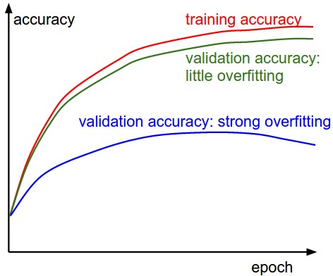

[figure not shown]

#### When to stop training?

- Monitor validation error to decide when to stop
  - “Patience” hyperparameter: number of epochs without improvement before stopping
  - **Early stopping**: terminate while validation set performance is better (a kind of regularization)

[figure not shown]

#### Other techniques

- Track the ratio of *weight updates* and *weight magnitudes*.
  $$\begin{equation}
  r=\frac{weight\_updates}{weight\_magnitudes}~
  \end{equation}$$
  - If this is too high to decrease learning rate
  - If it is too low to increase learning rate
- If dropout is not working for model, we should probably be using a bigger network.

#### Using a pretrained model

A **pretrained network** is a saved network that was previously trained on a large dataset

- A common and highly effective approach to deep learning on small image datasets is to use a pretrained network.
- There are two ways to use a pretrained network: *feature extraction* and *fine-tuning*.

[figure not shown]

#### Essential Skills to ML scientists/engineers

[figure not shown]

- **Design** a model
- **Run** + **Debug** the model
- **Revise** the model

## 14.7 References

[video not shown]